# MATHS1004 Mathematics for Data Science I

## Computer Lab 4

This lab is all about applications of eigenvalues and eigenvectors. We'll start with an example (taken from lectures in week 6) of eigenvalues, which we learn the theory of in week 7, and then a more data-driven example demonstrating the application of eigenvectors to principal component analysis (PCA), which we'll cover the theory for by week 8.

### Eigenvalues application: the Northern Spotted Owl

As discussed towards the end of the Thursday week 6 lecture (5 September), the growth in population numbers of juvenile and adult spotted owls can be modelled by the system of linear equations $$ \begin{align*} j_{k+1} &= a_k/3\\ a_{k+1} & = \beta j_k + 0.9a_k \end{align*} $$ where $j_k$ and $a_k$ represent the numbers of (female) juvenile and adult owls respectively in year $k$, and $\beta$ is the proportion of juvenile owls who survive to adulthood after year $k$. the 1/3 is the proportion of juveniles that are born to the number of adults in year $k$, and the 0.9 is the proportion of adults who survive year $k$.

We can write this in the following matrix form: $$ \mathbf{x}_{k+1} = A\mathbf{x}_k $$ where $$ \mathbf{x}_k = \begin{bmatrix} j_k\\ a_k \end{bmatrix} $$ and $$ A = \begin{bmatrix} 0 & 1/3\\ \beta & 0.9 \end{bmatrix} $$ (check that you believe this.)

Code this system up in the cells below using `numpy` for the matrices, and use a `for` loop to simulate this population for 100 years (say), starting from some initial population vector `x` (make up some numbers), and some value of $\beta$ (try $\beta = 0.1$ to start with like I did in the lecture if you want). Make a plot of the population sizes over time if you like, or just compare the population size after 100 years to the initial population size.

[Note: the past 3 labs have given you all the tools you need to be able to do this! You shouldn't feel afraid to give it a try. But you can also just go back and pause the 5 September lecture video at the appropriate point to copy down the code.]

```python
import numpy as np
import matplotlib.pyplot as plt
```

```python
# SOLUTION

survival_rate = 0.35

A = np.array([[0,1/3],[survival_rate,0.9]])
print(A)
```

```
[[0.   0.33]
 [0.35 0.9 ]]
```

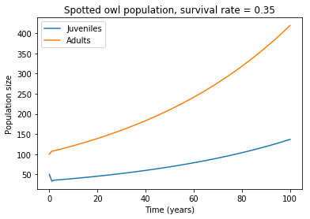

```python
# SOLUTION

x = np.array([50,100]) # initial population size

N_steps = 100
xt = [x] # create an array for plotting
for n in range(N_steps):
    x = np.matmul(A,x)
    xt.append(x)

# a little trick: convert list of arrays into a np.array
# (because we need to be careful with the matrix order that numpy gives to vectors)
xt = np.array(xt).T

plt.plot(xt[0,:],label="Juveniles")
plt.plot(xt[1,:],label="Adults")
plt.xlabel('Time (years)')
plt.ylabel('Population size')
plt.title('Spotted owl population, survival rate = '+str(survival_rate))
plt.legend()
plt.show()
```

Once you have the code: do some exploration! Try changing:

- The initial population size `x`;
- The number of years we are simulating the population for (`N_steps` in the lecture code);
- The survival rate $\beta$ (or `survival_rate` in the lecture code).

Exploring that last value is the most important thing! See if you can find the survival rate at which the population switches from dying out to surviving. Does changing the initial `x` or `N_steps` have a similar effect?

Once you have a feel for this system, I want you to calculate the [eigenvalues](https://docs.scipy.org/doc/numpy-1.15.1/reference/generated/numpy.linalg.eig.html) of the matrix $A$ in the cell below. You can do this by using `lambda_vals,V = np.linalg.eig(A)`, and then printing `lambda_vals`. (The matrix $V$ contains the *eigenvectors* -- we don't need to worry about these for now.)

```python
# SOLUTION

lambda_vals,V = np.linalg.eig(A)
print(lambda_vals)
```

[output not shown]

Go back and change the survival rate, and look at how the eigenvalues change.

**What do you notice happens to the eigenvalues as the population switches from going extinct to surviving?**

This is a deeply important result. We will discuss it more in lectures this week. It turns out that the long-term behaviour of this system (and therefore the survival or extinction of the species) is 100% determined by your observation about these eigenvalues -- if you know the eigenvalues you understand everything there is to know about the system!

That is a pretty great *summary statistic*, and piece of *dimension reduction* for this complicated system, down to effectively one number.